# Freight management(Shipment Cost Prediction)

Rajesh Kumar

9 December 2016

Problem Statement

# Freight management: Predict the cost of shipment

# Quickfreight is committed being the industry leader in logistic services through

# the continous investment in technology solutions and talented individuals.

# Quickfreight is the middle man between the customer and freight services.

# They will charge from the customer and pay to the freight services and during

# the transaction they will make their profit/revenue. The challenge is, given

# a request from a customer for shipment they would like to decide the estimated

# cost for the Carriers. This information will enable them to quote the best price

# for the customer and reduce the revenue leakages and increase their bottom line.

Data Exploration/Observations on Attributes

## Dependent/Traget Attribute

## ORDER_COST (Cost of the shipment)

## Independent/Predictor Variables

## ORDER_NBR

# This will be an unique number/ID for each new orders

# This will not have any contribution in predicting the cost. we can Drop this attribute

## EQUIPMENT_TYPE

# This is an important attribute, This will have impact on target attribute

# because based on the type e.g “R” Refrigerated , the shipment cost may change.

## CUSTOMER_MILES

# This would be treated as distance. Will have major impact on the shipment cost

## WEIGHT

# This is an important attribute, This will have impact on target attribute

# More weight, more shipment cost.

## FIRST_PICK_ZIP

# Map this to Pick up Regions

## FIRST_PICK_EARLY_APPT

# This will be used to create a new variable DELIVERY_DAY by subtracting

# (LAST_DELIVERY_EARLY_APPT - FIRST_PICK_EARLY_APPT), considering only days

## FIRST_PICK_LATE_APPT

# This variable can be dropped, as we have are considering “FIRST_PICK_EARLY_APPT”

## LAST_DELIVERY_ZIP

# Map this to Delivery Regions

## LAST_DELIVERY_EARLY_APPT

# This will be used to create a new variable DELIVERY_DAY by subtracting

# (AST_DELIVERY_EARLY_APPT - FIRST_PICK_EARLY_APPT) and considering only days

## LAST_DELIVERY_LATE_APPT

# This variable can be dropped, as we have are considering “LAST_DELIVERY_LATE_APPT”

## IS_HAZARDOUS

# This could be an important Attribute, This will have impact on target attribte

# because based on the type e.g “Y” HAZARDOUS , the shipment cost may change.

## CREATED_DATE

# Create new Variables like “CREATED_MONTH”, CREATED_DAY"

Load the Libararies

# Load the required Libraries

```r
require(dplyr)
require(lattice)
```

```r
require(ggplot2)
require(h2o)
require(car)
require(MASS)
```

Environment Variables

```r
## Clear Environment Variables
rm(list=ls(all=TRUE))
```

Load the CSV files

## Load the Data from csv files

```r
# Main data file
Freight_Data = read.csv("Spot_Freight_Data.csv" ,header=T ,sep = "," ,
                        na.strings = c("",NA) )

# Region Pick look up file
Region_Pick_Lookup_Data = read.csv("Region_Lookups_Pick.csv" ,header=T ,sep = "," ,
                                   na.strings = c("",NA) )

# Region Delivery look up file
Region_Delivery_Lookup_Data = read.csv("Region_Lookups_Delivery.csv" ,header=T ,sep = "," ,
                                       na.strings = c("",NA) )

# Market Pick look up file
Market_Pick_Lookup_Data = read.csv("Market_Lookups_Pick.csv" ,header=T ,sep = "," ,
                                   na.strings = c("",NA) )
# Market Delivery look up file
Market_Delivery_Lookup_Data = read.csv("Market_Lookups_Delivery.csv" ,header=T ,sep = "," ,
                                       na.strings = c("",NA) )
# Equipment look up file
Equipment_Data = read.csv("Equipment_Codes1.csv" ,header=T ,sep = "," ,na.strings = c("",NA) )
```

Summary

## Summary

```r
dim(Freight_Data)
```

```
## [1] 37699    13
```

```r
head(Freight_Data)
```

```
##   ORDER_NBR EQUIPMENT_TYPE CUSTOMER_MILES WEIGHT ORDER_COST FIRST_PICK_ZIP
## 1    167159              R           1832  41976       3450          67501
## 2    167160              R           1136  41344       2800          67501
## 3    167161              R           1832  42000       3900          67501
## 4    167162              R           1832  42000       3700          67501
## 5    167163              R           1744  41344       3650          67501
## 6    167164              R            941  41000       1600          33309
##   FIRST_PICK_EARLY_APPT FIRST_PICK_LATE_APPT LAST_DELIVERY_ZIP
## 1      01-06-2016 00:00     01-06-2016 00:00             98372
## 2      01-02-2016 00:00     01-03-2016 00:00             24153
## 3      01-06-2016 00:00     01-06-2016 00:00             98372
## 4      01-04-2016 00:00     01-04-2016 00:00             98372
## 5      01-04-2016 00:00     01-04-2016 00:00             97015
## 6      01-04-2016 00:00     01-04-2016 00:00             23224
##   LAST_DELIVERY_EARLY_APPT LAST_DELIVERY_LATE_APPT IS_HAZARDOUS
## 1         01-11-2016 00:00        01-11-2016 00:00            N
## 2         01-05-2016 00:00        01-05-2016 00:00            N
## 3         01-08-2016 00:00              01-08-2016            N
## 4         01-08-2016 00:00        01-08-2016 00:00            N
## 5         01-08-2016 00:00        01-08-2016 00:00            N
## 6         01-06-2016 00:00        01-06-2016 00:00            N
##       CREATED_DATE
## 1 01-01-2016 00:00
## 2 01-01-2016 00:00
## 3 01-01-2016 00:00
## 4 01-01-2016 00:00
## 5 01-01-2016 00:00
## 6 01-02-2016 00:00
```

```r
str(Freight_Data)
```

```
## 'data.frame':    37699 obs. of  13 variables:
##  $ ORDER_NBR               : int  167159 167160 167161 167162 167163 167164 167164 167165 167166 167167 ...
##  $ EQUIPMENT_TYPE          : Factor w/ 30 levels "AIR","D-LTL",..: 14 14 14 14 14 14 14 25 20 20 ...
##  $ CUSTOMER_MILES          : int  1832 1136 1832 1832 1744 941 941 748 0 268 ...
##  $ WEIGHT                  : int  41976 41344 42000 42000 41344 41000 41000 21950 23000 5000 ...
##  $ ORDER_COST              : num  3450 2800 3900 3700 3650 1600 1600 2400 3050 550 ...
##  $ FIRST_PICK_ZIP          : Factor w/ 1181 levels " N5W 6C7","0000",..: 918 918 918 918 918 337 337 853 1041 235 ...
##  $ FIRST_PICK_EARLY_APPT   : Factor w/ 5452 levels "01-02-2016 00:00",..: 68 1 68 21 21 21 21 68 44 21 ...
##  $ FIRST_PICK_LATE_APPT    : Factor w/ 5283 levels "01-02-2016 00:00",..: 67 7 67 21 21 21 21 67 44 21 ...
##  $ LAST_DELIVERY_ZIP       : Factor w/ 2386 levels "00302","00779",..: 2320 486 2320 2320 2284 464 459 360 2386 454 ...
##  $ LAST_DELIVERY_EARLY_APPT: Factor w/ 6268 levels "01-03-2016 00:00",..: 174 29 103 103 103 51 51 75 103 29 ...
##  $ LAST_DELIVERY_LATE_APPT : Factor w/ 6389 levels "01-03-2016 00:00",..: 185 27 110 111 111 53 53 80 111 27 ...
##  $ IS_HAZARDOUS            : Factor w/ 2 levels "N","Y": 1 1 1 1 1 1 1 1 1 1 ...
##  $ CREATED_DATE            : Factor w/ 20936 levels "01-01-2016 00:00",..: 1 1 1 1 1 7 7 7 7 7 ...
```

```r
summary(Freight_Data)
```

```
##    ORDER_NBR      EQUIPMENT_TYPE  CUSTOMER_MILES       WEIGHT
##  Min.   :-63847   V      :24804   Min.   :   0.0   Min.   :      0
##  1st Qu.:171266   VR     : 5078   1st Qu.: 254.0   1st Qu.:   8000
##  Median :176176   R      : 4031   Median : 437.0   Median :  18078
##  Mean   :177921   HB     :  356   Mean   : 566.3   Mean   :  22352
##  3rd Qu.:184530   F      :  335   3rd Qu.: 696.0   3rd Qu.:  41054
##  Max.   :192944   (Other):  994   Max.   :3960.0   Max.   :2695680
##  NA's   :1        NA's   : 2101   NA's   :1        NA's   :1
##    ORDER_COST     FIRST_PICK_ZIP       FIRST_PICK_EARLY_APPT
##  Min.   :   0.0   47805  : 2949   02-08-2016 00:00:  249
##  1st Qu.: 335.0   50010  : 1944   1-27-2016 0:00  :  238
##  Median : 650.0   29016  : 1941   02-10-2016 00:00:  234
##  Mean   : 792.7   17745  : 1782   02-09-2016 00:00:  233
##  3rd Qu.:1100.0   24382  : 1749   1-20-2016 0:00  :  231
##  Max.   :6400.0   (Other):27333   (Other)         :36102
##  NA's   :181      NA's   :    1   NA's            :  412
##        FIRST_PICK_LATE_APPT LAST_DELIVERY_ZIP     LAST_DELIVERY_EARLY_APPT
##  02-08-2016 00:00:  241     29650  : 1245     1-28-2016 0:00  :  257
##  02-09-2016 00:00:  230     07885  :  844     02-10-2016 00:00:  247
##  1/27/2016 0:00  :  227     53094  :  807     02-11-2016 00:00:  243
##  1/20/2016 0:00  :  226     24382  :  720     02-08-2016 00:00:  239
##  1/26/2016 0:00  :  224     43607  :  445     1-20-2016 0:00  :  239
##  (Other)         :35348     (Other):33636     (Other)         :35957
##  NA's            : 1203     NA's   :    2     NA's            :  517
##      LAST_DELIVERY_LATE_APPT IS_HAZARDOUS           CREATED_DATE
##  1/28/2016 0:00  :  255      N   :37403   02-04-2016 00:00:  388
##  02-11-2016 00:00:  240      Y   :  295   2-15-2016 0:00  :  314
##  02-10-2016 00:00:  230      NA's:    1   1-13-2016 0:00  :  303
##  1/20/2016 0:00  :  229                   02-11-2016 00:00:  294
##  02-09-2016 00:00:  228                   1-14-2016 0:00  :  293
##  (Other)         :35319                   (Other)         :36106
##  NA's            : 1198                   NA's            :    1
```

###### Expand the Equipment Type

## Do the lookup using Merge function

```r
Freight_Data <- merge(x=Freight_Data, y=Equipment_Data, by.x="EQUIPMENT_TYPE", by.y="EQUIPMENT_TYPE")
table(Freight_Data$EQUIP_TYPE)
```

```
##
##  DRY FREIGHT      FLATBED       IGNORE REFRIGERATED
##        32423          349          569         4120
```

Data Exploration

## Univariate Analaysis:

# Continuous Variables:

# Understand the central tendency and spread of the variable.

# ORDER_NBR (No need so we can drop this variable)

# CUSTOMER_MILES

# WEIGHT

# ORDER_COST

## 1) CUSTOMER_MILES/DISTANCE

```r
# Summary

summary(Freight_Data$CUSTOMER_MILES)
```

```
##    Min. 1st Qu.  Median    Mean 3rd Qu.    Max.    NA's
##     0.0   254.0   436.0   566.1   695.0  3960.0       1
```

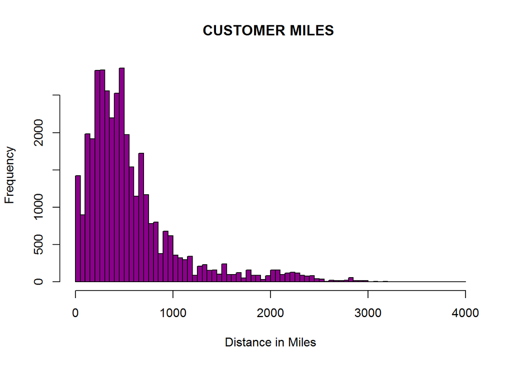

```r
# Histogram

h_miles <- hist(Freight_Data$CUSTOMER_MILES,
                main="CUSTOMER MILES ",
                xlab="Distance in Miles",
                breaks=100,
                col="darkmagenta")
```

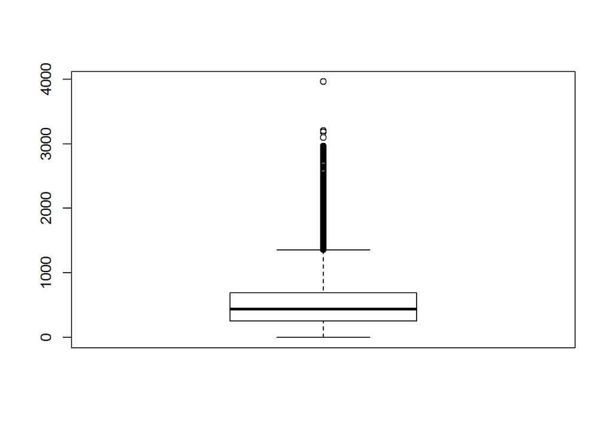

```r
## Box plot

boxplot(Freight_Data$CUSTOMER_MILES)
```

```r
# All the above shows a lot of Customer Miles are zeros (0) and distribution is right
# Skewed, so better to remove these records.

length(Freight_Data$CUSTOMER_MILES[Freight_Data$CUSTOMER_MILES == 0])
```

```
## [1] 631
```

```r
# Remove the Customer Miles having Zeros.

Freight_Data$CUSTOMER_MILES <- ifelse(Freight_Data$CUSTOMER_MILES==0,NA,Freight_Data$CUSTOMER_MILES)
table(is.na(Freight_Data$CUSTOMER_MILES))
```

```
##
## FALSE  TRUE
## 36830   631
```

```r
Freight_Data <- Freight_Data[!is.na(Freight_Data$CUSTOMER_MILES),]
```

## 2) WEIGHT

```r
# Summary
summary(Freight_Data$WEIGHT)
```

```
##    Min. 1st Qu.  Median    Mean 3rd Qu.    Max.
##       0    8000   17270   22180   41040 2696000
```

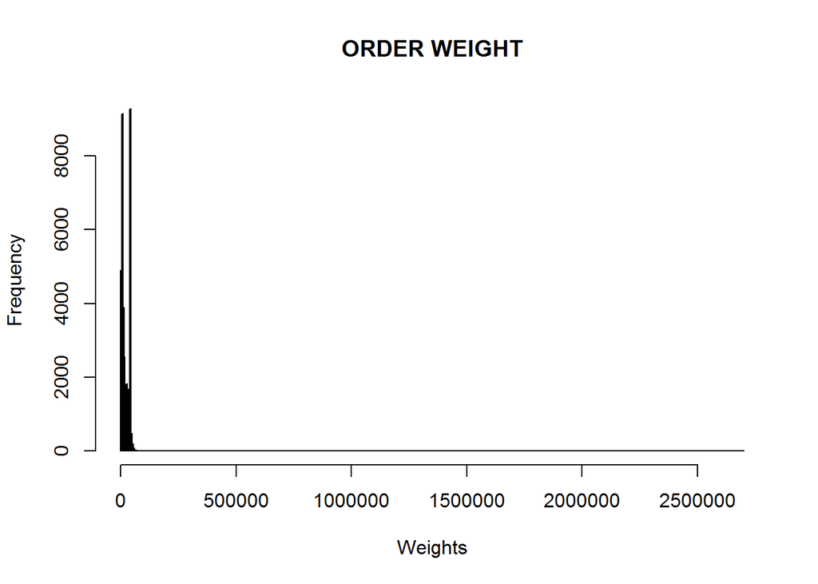

```r
## Histogram

h_wt <- hist(Freight_Data$WEIGHT,
             main="ORDER WEIGHT",
             xlab="Weights",
             breaks=500)
```

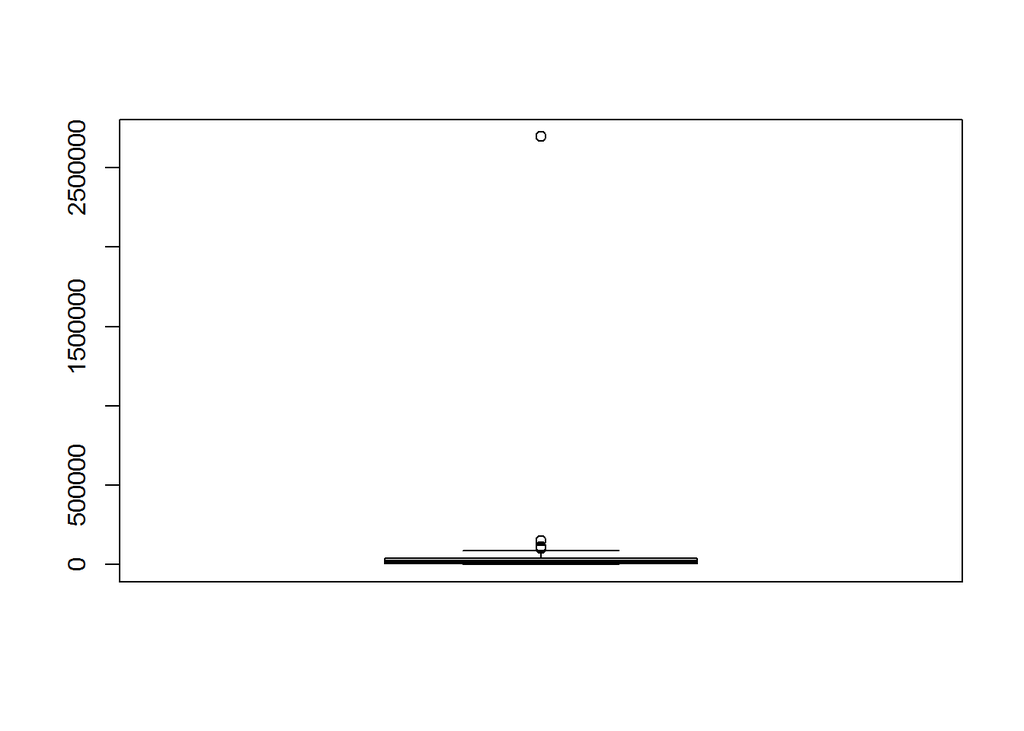

```r
## Box Plot

boxplot(Freight_Data$WEIGHT)
```

```r
# All the above shows a lot of Weights are zeros (0) so better to remove
# these records. Also remove one record having weight > 200000 (Treating as outlier)

length(Freight_Data$WEIGHT[Freight_Data$WEIGHT == 0])
```

```
## [1] 3449
```

```r
length(Freight_Data$WEIGHT[Freight_Data$WEIGHT > 200000])
```

```
## [1] 1
```

```r
# Remove the outliers and Zeros
Freight_Data$WEIGHT <- ifelse((Freight_Data$WEIGHT == 0) | (Freight_Data$WEIGHT > 200000),
                              NA,Freight_Data$WEIGHT)
table(is.na(Freight_Data$WEIGHT))
```

```
##
## FALSE  TRUE
## 33380  3450
```

```r
Freight_Data <- Freight_Data[!is.na(Freight_Data$WEIGHT),]
```

## 3) ORDER_COST

```r
# Summary

summary(Freight_Data$ORDER_COST)
```

```
##    Min. 1st Qu.  Median    Mean 3rd Qu.    Max.    NA's
##     0.0   385.0   675.0   825.9  1150.0  6400.0      53
```

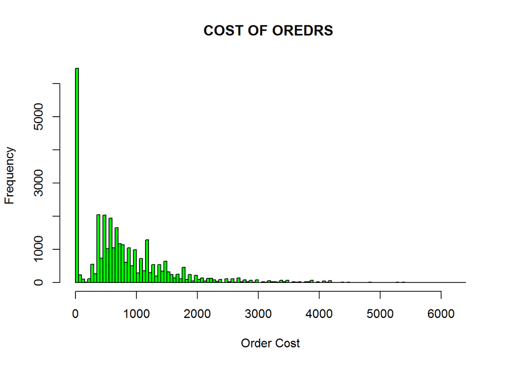

```r
# Histogram

h_cost <- hist(Freight_Data$ORDER_COST,
               main="COST OF OREDRS ",
               xlab="Order Cost",
               breaks=100,
               col="Green")
```

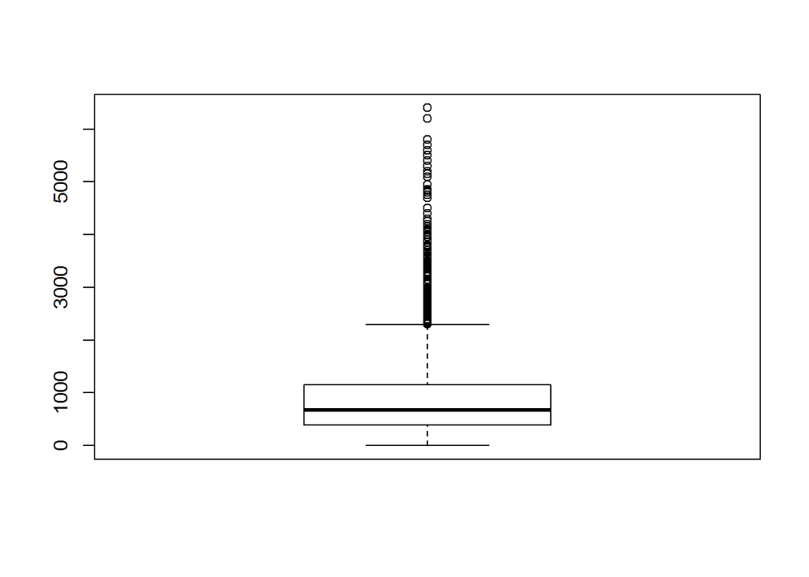

```r
# Box Plot

boxplot(Freight_Data$ORDER_COST)
```

```r
# The plot is showing Right Skewed Distribution and there are a lots of zeros (0) in the cost

length(Freight_Data$ORDER_COST[Freight_Data$ORDER_COST == 0])
```

```
## [1] 6505
```

```r
# There are about 6505 rows where Costs are 0.It's better to replace these
# records with NA and then remove these records.
# Also the summary shows
# Min.   :   0.0
# Max.   :6400.00
# So seems that  record having order cost = 0.01 is outlier.
# So remove this record

Freight_Data$ORDER_COST <- ifelse(Freight_Data$ORDER_COST < 1,NA, as.numeric(Freight_Data$ORDER_COST))
table(is.na(Freight_Data$ORDER_COST))
```

```
##
## FALSE  TRUE
## 26874  6506
```

```r
Freight_Data <- Freight_Data[!is.na(Freight_Data$ORDER_COST),]
```

Categorical Vribales

## Categorical Variables (frequency table to understand distribution of each category)

# EQUIPMENT_TYPE

# FIRST_PICK_ZIP

# LAST_DELIVERY_ZIP

# IS_HAZARDOUS

# CREATED_DATE

## 1) EQUIPMENT_TYPE

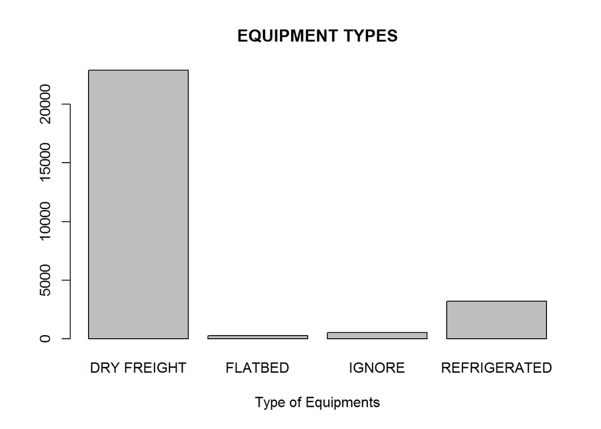

```r
# The major category is "DRY Freight"
counts <- table(Freight_Data$EQUIP_TYPE)
barplot(counts, main="EQUIPMENT TYPES", xlab="Type of Equipments")
```

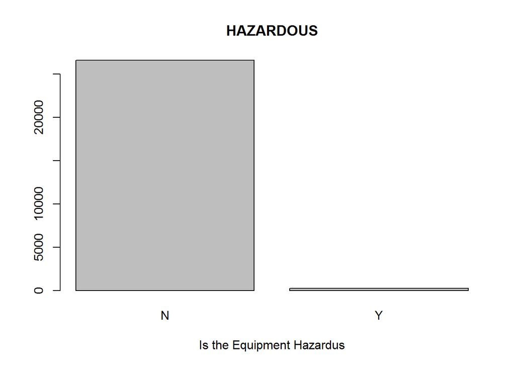

```r
## 2) IS_HAZARDOUS

counts <- table(Freight_Data$IS_HAZARDOUS)
barplot(counts, main="HAZARDOUS", xlab="Is the Equipment Hazardus")
```

```r
# Major category is "N" not hazardous
```